# project-loan

## Module : Supervised learing

Project : Thera Bank Personal Loan Campaign

Data Description: The dataset contains data on 5000 customers. The data include customer demographic information (age, income, etc.), the customer's relationship with the bank (mortgage, securities account, etc.), and the customer response to the last personal loan campaign (Personal Loan). Among these 5000 customers, only 480 (= 9.6%) accepted the personal loan that was offered to them in the earlier campaign.

Attribute Information:

- ID: Customer ID
- Age: Customer's age in completed years
- Experience: #years of professional experience
- Income: Annual income of the customer($000).
- ZIP Code: Home Address ZIP code.
- Family: Family size of the customer.
- CCAvg: Avg. spending on credit cards per month ($000.
- Education: Education Level. 1: Undergrad; 2: Graduate; 3: Advanced/Professional
- Mortgage: Value of house mortgage if any.($000)
- Personal Loan: Did this customer accept the personal loan offered in the last campaign?
- Securities Account: Doesthe customer have a securities account with the bank?
- CD Account: Doesthe customer have a certificate of deposit (CD) account with the bank?
- Online: Does the customer use internet banking facilities?
- Credit card: Doesthe customer use a credit card issued by the bank?

Objective: The classification goal is to predict the likelihood of a liability customer buying personal loans.

GitHub link: https://github.com/GreatLearningAIML1/gl-pgp-aiml-uta-intl-may20-ssetty3

```python
# Importing all needed Basic libary

import pandas as pd
import numpy as np
import seaborn as sns #visualisation
import matplotlib.pyplot as plt #visualisation
%matplotlib inline
sns.set(style="ticks", color_codes=True)
import scipy.stats as stats
```

## 1. Statistical Summary and Null value check

```python
# Understanding the data Set
Bank_data= pd.read_csv('Bank_Personal_Loan_Modelling.csv')
Bank_data.head(5)
```

|  | ID | Age | Experience | Income | ZIP Code | Family | CCAvg | Education | Mortgage | Personal Loan | Securities Account | CD Account | Online | CreditCard |
| --- | --- | --- | --- | --- | --- | --- | --- | --- | --- | --- | --- | --- | --- | --- |
| 0 | 1 | 25 | 1 | 49 | 91107 | 4 | 1.6 | 1 | 0 | 0 | 1 | 0 | 0 | 0 |
| 1 | 2 | 45 | 19 | 34 | 90089 | 3 | 1.5 | 1 | 0 | 0 | 1 | 0 | 0 | 0 |
| 2 | 3 | 39 | 15 | 11 | 94720 | 1 | 1.0 | 1 | 0 | 0 | 0 | 0 | 0 | 0 |
| 3 | 4 | 35 | 9 | 100 | 94112 | 1 | 2.7 | 2 | 0 | 0 | 0 | 0 | 0 | 0 |
| 4 | 5 | 35 | 8 | 45 | 91330 | 4 | 1.0 | 2 | 0 | 0 | 0 | 0 | 0 | 1 |

```python
# To see the shape of the data Frame
print('The shape of the data frame Rows*Columns is = ', Bank_data.shape , "\n-------------------------------------------")
print(Bank_data.info())
```

```
The shape of the data frame Rows*Columns is =  (5000, 14)
-------------------------------------------
<class 'pandas.core.frame.DataFrame'>
RangeIndex: 5000 entries, 0 to 4999
Data columns (total 14 columns):
 #   Column              Non-Null Count  Dtype
---  ------              --------------  -----
 0   ID                  5000 non-null   int64
 1   Age                 5000 non-null   int64
 2   Experience          5000 non-null   int64
 3   Income              5000 non-null   int64
 4   ZIP Code            5000 non-null   int64
 5   Family              5000 non-null   int64
 6   CCAvg               5000 non-null   float64
 7   Education           5000 non-null   int64
 8   Mortgage            5000 non-null   int64
 9   Personal Loan       5000 non-null   int64
 10  Securities Account  5000 non-null   int64
 11  CD Account          5000 non-null   int64
 12  Online              5000 non-null   int64
 13  CreditCard          5000 non-null   int64
dtypes: float64(1), int64(13)
memory usage: 546.9 KB
None
```

```python
# Data types are in good shape.
#Check for missing data
print (Bank_data.isna().sum())
```

```
ID                    0
Age                   0
Experience            0
Income                0
ZIP Code              0
Family                0
CCAvg                 0
Education             0
Mortgage              0
Personal Loan         0
Securities Account    0
CD Account            0
Online                0
CreditCard            0
dtype: int64
```

```python
# No Missing values
# Age:Customer's age in completed years, when checked manully in  .CSV file found couple of -1,-2 data with -ve experiance
## considering that column to cleanup and replace with -ve data with median value. Counting the values which are -ve
Bank_data[Bank_data['Experience'] < 0]['Experience'].count()
```

```
52
```

```python
# method locate and replace with median value in experiance
Exp = Bank_data.loc[Bank_data['Experience']>0]
negExp =Bank_data.Experience < 0
mylist =Bank_data.loc[negExp]['ID'].tolist()
print(mylist,"\n------------")
print('The Median experiance is=',Bank_data['Experience'].median(),"\n------------")
negExp.value_counts()
```

```
[90, 227, 316, 452, 525, 537, 541, 577, 584, 598, 650, 671, 687, 794, 890, 910, 1174, 1429, 1523, 1906, 2103, 2431, 2467, 2546, 2619, 2718, 2849, 2877, 2963, 2981, 3077, 3131, 3158, 3280, 3285, 3293, 3395, 3426, 3627, 3797, 3825, 3888, 3947, 4016, 4089, 4117, 4286, 4412, 4482, 4515, 4583, 4958]
------------
The Median experiance is= 20.0
------------
```

```
False    4948
True       52
Name: Experience, dtype: int64
```

```python
for id in mylist:
    age = Bank_data.loc[np.where(Bank_data['ID']==id)]["Age"].tolist()[0]
    education =Bank_data.loc[np.where(Bank_data['ID']==id)]["Education"].tolist()[0]
    df_filtered = Exp[(Exp.Age == age) & (Exp.Education == education)]
    exp = df_filtered['Experience'].median()
    Bank_data.loc[Bank_data.loc[np.where(Bank_data['ID']==id)].index, 'Experience'] = exp
    exit
Bank_data[Bank_data['Experience'] < 0]['Experience'].count() # check DF for -ve experiance
```

```
0
```

```python
print(Bank_data['Experience'].median(),"\n") # Check Median experiance
```

```
20.0
```

```python
Bank_data.describe() # Stastical Summary for Data Set
```

|  | ID | Age | Experience | Income | ZIP Code | Family | CCAvg | Education | Mortgage | Personal Loan | Securities Account | CD Account | Online | CreditCard |
| --- | --- | --- | --- | --- | --- | --- | --- | --- | --- | --- | --- | --- | --- | --- |
| count | 5000.000000 | 5000.000000 | 4971.000000 | 5000.000000 | 5000.000000 | 5000.000000 | 5000.000000 | 5000.000000 | 5000.000000 | 5000.000000 | 5000.000000 | 5000.00000 | 5000.000000 | 5000.000000 |
| mean | 2500.500000 | 45.338400 | 20.243211 | 73.774200 | 93152.503000 | 2.396400 | 1.937938 | 1.881000 | 56.498800 | 0.096000 | 0.104400 | 0.06040 | 0.596800 | 0.294000 |
| std | 1443.520003 | 11.463166 | 11.359189 | 46.033729 | 2121.852197 | 1.147663 | 1.747659 | 0.839869 | 101.713802 | 0.294621 | 0.305809 | 0.23825 | 0.490589 | 0.455637 |
| min | 1.000000 | 23.000000 | 0.000000 | 8.000000 | 9307.000000 | 1.000000 | 0.000000 | 1.000000 | 0.000000 | 0.000000 | 0.000000 | 0.00000 | 0.000000 | 0.000000 |
| 25% | 1250.750000 | 35.000000 | 10.000000 | 39.000000 | 91911.000000 | 1.000000 | 0.700000 | 1.000000 | 0.000000 | 0.000000 | 0.000000 | 0.00000 | 0.000000 | 0.000000 |
| 50% | 2500.500000 | 45.000000 | 20.000000 | 64.000000 | 93437.000000 | 2.000000 | 1.500000 | 2.000000 | 0.000000 | 0.000000 | 0.000000 | 0.00000 | 1.000000 | 0.000000 |
| 75% | 3750.250000 | 55.000000 | 30.000000 | 98.000000 | 94608.000000 | 3.000000 | 2.500000 | 3.000000 | 101.000000 | 0.000000 | 0.000000 | 0.00000 | 1.000000 | 1.000000 |
| max | 5000.000000 | 67.000000 | 43.000000 | 224.000000 | 96651.000000 | 4.000000 | 10.000000 | 3.000000 | 635.000000 | 1.000000 | 1.000000 | 1.00000 | 1.000000 | 1.000000 |

## 2. EDA

```python
print(Bank_data.info())
```

```
<class 'pandas.core.frame.DataFrame'>
RangeIndex: 5000 entries, 0 to 4999
Data columns (total 14 columns):
 #   Column              Non-Null Count  Dtype
---  ------              --------------  -----
 0   ID                  5000 non-null   int64
 1   Age                 5000 non-null   int64
 2   Experience          4971 non-null   float64
 3   Income              5000 non-null   int64
 4   ZIP Code            5000 non-null   int64
 5   Family              5000 non-null   int64
 6   CCAvg               5000 non-null   float64
 7   Education           5000 non-null   int64
 8   Mortgage            5000 non-null   int64
 9   Personal Loan       5000 non-null   int64
 10  Securities Account  5000 non-null   int64
 11  CD Account          5000 non-null   int64
 12  Online              5000 non-null   int64
 13  CreditCard          5000 non-null   int64
dtypes: float64(2), int64(12)
memory usage: 546.9 KB
None
```

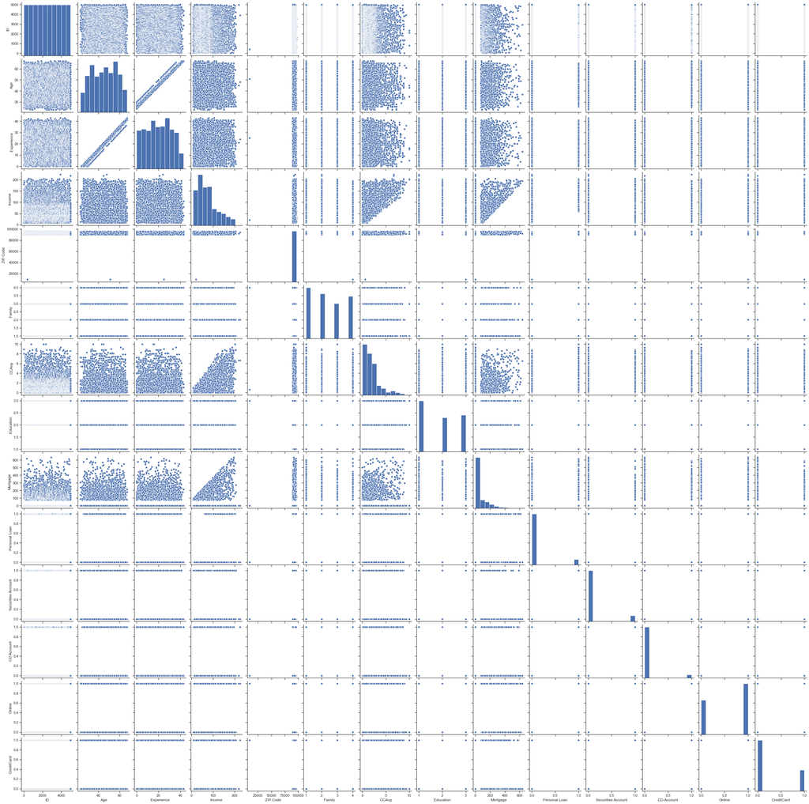

```python
sns.pairplot(Bank_data)
```

Observations :

```python
# the correlation coefficient between every pair of attributes
Bank_data.corr()
```

|  | ID | Age | Experience | Income | ZIP Code | Family | CCAvg | Education | Mortgage | Personal Loan | Securities Account | CD Account | Online | CreditCard |
| --- | --- | --- | --- | --- | --- | --- | --- | --- | --- | --- | --- | --- | --- | --- |
| ID | 1.000000 | -0.008473 | -0.009308 | -0.017695 | 0.013432 | -0.016797 | -0.024675 | 0.021463 | -0.013920 | -0.024801 | -0.016972 | -0.006909 | -0.002528 | 0.017028 |
| Age | -0.008473 | 1.000000 | 0.994159 | -0.055269 | -0.029216 | -0.046418 | -0.052012 | 0.041334 | -0.012539 | -0.007726 | -0.000436 | 0.008043 | 0.013702 | 0.007681 |
| Experience | -0.009308 | 0.994159 | 1.000000 | -0.048095 | -0.030649 | -0.049420 | -0.047694 | 0.013075 | -0.012935 | -0.011498 | 0.001059 | 0.007381 | 0.014501 | 0.007935 |
| Income | -0.017695 | -0.055269 | -0.048095 | 1.000000 | -0.016410 | -0.157501 | 0.645984 | -0.187524 | 0.206806 | 0.502462 | -0.002616 | 0.169738 | 0.014206 | -0.002385 |
| ZIP Code | 0.013432 | -0.029216 | -0.030649 | -0.016410 | 1.000000 | 0.011778 | -0.004061 | -0.017377 | 0.007383 | 0.000107 | 0.004704 | 0.019972 | 0.016990 | 0.007691 |
| Family | -0.016797 | -0.046418 | -0.049420 | -0.157501 | 0.011778 | 1.000000 | -0.109275 | 0.064929 | -0.020445 | 0.061367 | 0.019994 | 0.014110 | 0.010354 | 0.011588 |
| CCAvg | -0.024675 | -0.052012 | -0.047694 | 0.645984 | -0.004061 | -0.109275 | 1.000000 | -0.136124 | 0.109905 | 0.366889 | 0.015086 | 0.136534 | -0.003611 | -0.006689 |
| Education | 0.021463 | 0.041334 | 0.013075 | -0.187524 | -0.017377 | 0.064929 | -0.136124 | 1.000000 | -0.033327 | 0.136722 | -0.010812 | 0.013934 | -0.015004 | -0.011014 |
| Mortgage | -0.013920 | -0.012539 | -0.012935 | 0.206806 | 0.007383 | -0.020445 | 0.109905 | -0.033327 | 1.000000 | 0.142095 | -0.005411 | 0.089311 | -0.005995 | -0.007231 |
| Personal Loan | -0.024801 | -0.007726 | -0.011498 | 0.502462 | 0.000107 | 0.061367 | 0.366889 | 0.136722 | 0.142095 | 1.000000 | 0.021954 | 0.316355 | 0.006278 | 0.002802 |
| Securities Account | -0.016972 | -0.000436 | 0.001059 | -0.002616 | 0.004704 | 0.019994 | 0.015086 | -0.010812 | -0.005411 | 0.021954 | 1.000000 | 0.317034 | 0.012627 | -0.015028 |
| CD Account | -0.006909 | 0.008043 | 0.007381 | 0.169738 | 0.019972 | 0.014110 | 0.136534 | 0.013934 | 0.089311 | 0.316355 | 0.317034 | 1.000000 | 0.175880 | 0.278644 |
| Online | -0.002528 | 0.013702 | 0.014501 | 0.014206 | 0.016990 | 0.010354 | -0.003611 | -0.015004 | -0.005995 | 0.006278 | 0.012627 | 0.175880 | 1.000000 | 0.004210 |
| CreditCard | 0.017028 | 0.007681 | 0.007935 | -0.002385 | 0.007691 | 0.011588 | -0.006689 | -0.011014 | -0.007231 | 0.002802 | -0.015028 | 0.278644 | 0.004210 | 1.000000 |

```python
#  the covariance of each attribute against every other attribute
Bank_data.cov()
```

|  | ID | Age | Experience | Income | ZIP Code | Family | CCAvg | Education | Mortgage | Personal Loan | Securities Account | CD Account | Online | CreditCard |
| --- | --- | --- | --- | --- | --- | --- | --- | --- | --- | --- | --- | --- | --- | --- |
| ID | 2.083750e+06 | -140.198640 | -152.629426 | -1175.826465 | 4.113995e+04 | -27.827566 | -62.250047 | 26.021304 | -2043.804561 | -10.547710 | -7.492298 | -2.376275 | -1.790558 | 11.199840 |
| Age | -1.401986e+02 | 131.404166 | 128.457033 | -29.164822 | -7.106319e+02 | -0.610664 | -1.041997 | 0.397949 | -14.619518 | -0.026092 | -0.001529 | 0.021965 | 0.077058 | 0.040118 |
| Experience | -1.526294e+02 | 128.457033 | 129.031179 | -25.165546 | -7.395628e+02 | -0.644606 | -0.945039 | 0.124799 | -14.958303 | -0.038580 | 0.003674 | 0.020030 | 0.080812 | 0.041083 |
| Income | -1.175826e+03 | -29.164822 | -25.165546 | 2119.104235 | -1.602857e+03 | -8.320957 | 51.970200 | -7.250120 | 968.321693 | 6.814640 | -0.036834 | 1.861611 | 0.320822 | -0.050025 |
| ZIP Code | 4.113995e+04 | -710.631942 | -739.562829 | -1602.857394 | 4.502257e+06 | 28.681947 | -15.058132 | -30.966736 | 1593.492802 | 0.067125 | 3.052497 | 10.096438 | 17.685947 | 7.436005 |
| Family | -2.782757e+01 | -0.610664 | -0.644606 | -8.320957 | 2.868195e+01 | 1.317130 | -0.219174 | 0.062584 | -2.386602 | 0.020750 | 0.007017 | 0.003858 | 0.005830 | 0.006060 |
| CCAvg | -6.225005e+01 | -1.041997 | -0.945039 | 51.970200 | -1.505813e+01 | -0.219174 | 3.054312 | -0.199803 | 19.536778 | 0.188910 | 0.008063 | 0.056850 | -0.003096 | -0.005327 |
| Education | 2.602130e+01 | 0.397949 | 0.124799 | -7.250120 | -3.096674e+01 | 0.062584 | -0.199803 | 0.705380 | -2.847012 | 0.033831 | -0.002777 | 0.002788 | -0.006182 | -0.004215 |
| Mortgage | -2.043805e+03 | -14.619518 | -14.958303 | 968.321693 | 1.593493e+03 | -2.386602 | 19.536778 | -2.847012 | 10345.697538 | 4.258167 | -0.168308 | 2.164305 | -0.299144 | -0.335114 |
| Personal Loan | -1.054771e+01 | -0.026092 | -0.038580 | 6.814640 | 6.712543e-02 | 0.020750 | 0.188910 | 0.033831 | 4.258167 | 0.086801 | 0.001978 | 0.022206 | 0.000907 | 0.000376 |
| Securities Account | -7.492298e+00 | -0.001529 | 0.003674 | -0.036834 | 3.052497e+00 | 0.007017 | 0.008063 | -0.002777 | -0.168308 | 0.001978 | 0.093519 | 0.023099 | 0.001894 | -0.002094 |
| CD Account | -2.376275e+00 | 0.021965 | 0.020030 | 1.861611 | 1.009644e+01 | 0.003858 | 0.056850 | 0.002788 | 2.164305 | 0.022206 | 0.023099 | 0.056763 | 0.020557 | 0.030248 |
| Online | -1.790558e+00 | 0.077058 | 0.080812 | 0.320822 | 1.768595e+01 | 0.005830 | -0.003096 | -0.006182 | -0.299144 | 0.000907 | 0.001894 | 0.020557 | 0.240678 | 0.000941 |
| CreditCard | 1.119984e+01 | 0.040118 | 0.041083 | -0.050025 | 7.436005e+00 | 0.006060 | -0.005327 | -0.004215 | -0.335114 | 0.000376 | -0.002094 | 0.030248 | 0.000941 | 0.207606 |

### Trying to understand/ visualize relationships of the data

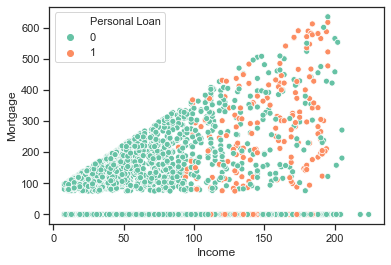

```python
#to understand relationship b/w Income mortgage wrt to Personal loan
sns.scatterplot(Bank_data['Income'], Bank_data['Mortgage'],hue=Bank_data['Personal Loan'], palette='Set2')
```

##### observation:

- Income group between 200 to 100 can be targeted for the personal loans

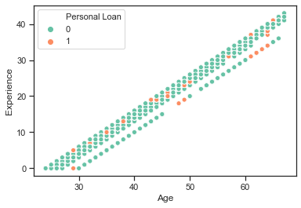

```python
sns.scatterplot(Bank_data['Age'], Bank_data['Experience'],hue=Bank_data['Personal Loan'], palette='Set2')
```

##### observation:

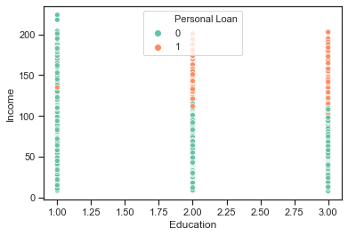

```python
sns.scatterplot(Bank_data['Education'], Bank_data['Income'],hue=Bank_data['Personal Loan'], palette='Set2')
```

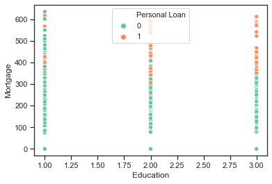

```python
sns.scatterplot(Bank_data['Education'], Bank_data['Mortgage'],hue=Bank_data['Personal Loan'], palette='Set2')
```

##### observation:

- Group 1 educated have taken less personal loan, where group 3 and 2 have more Personal loans

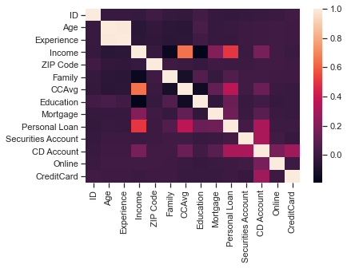

```python
sns.heatmap(Bank_data.corr(), annot=False)
```

Observation

- Age and Experience has high correlated.
- personal loan and income are moderatly co-rrelated.
- CCavg and income are moderatly co-rrelated.
- CD account and personal loan have mild corelation *

```python
Bank_data['Age'].describe()
```

```
count    5000.000000
mean       45.338400
std        11.463166
min        23.000000
25%        35.000000
50%        45.000000
75%        55.000000
max        67.000000
Name: Age, dtype: float64
```

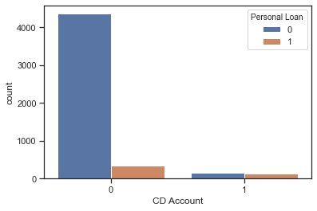

```python
sns.countplot(x='CD Account',data=Bank_data,hue='Personal Loan')
```

Observation:

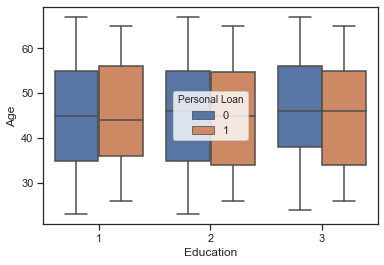

```python
sns.boxplot(x="Education",y='Age',hue='Personal Loan', data=Bank_data)
```

Observation:

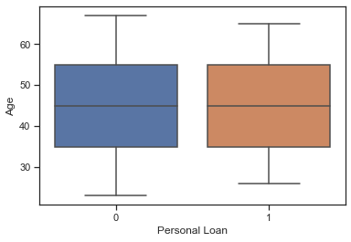

```python
# To Visualize the oppurtunity of customers.
# to see if any outliers here thats going to create biasness

sns.boxplot(x='Personal Loan',y='Age',data=Bank_data)
```

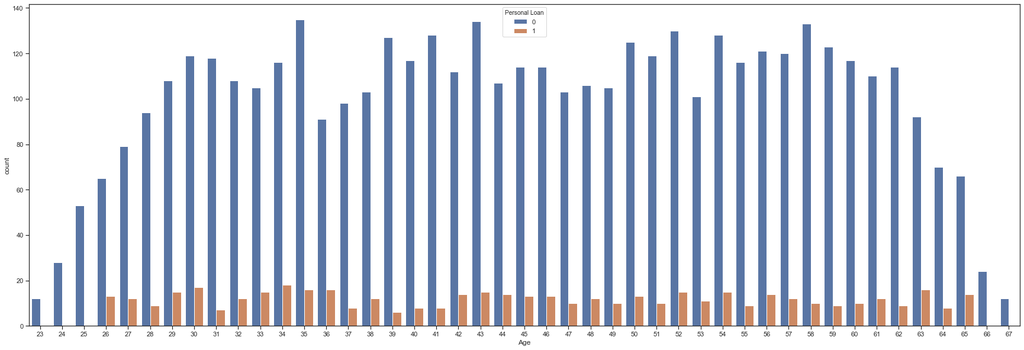

```python
plt.figure(figsize=(30,10))
sns.countplot(x='Age',data=Bank_data,hue='Personal Loan')
```

```
Age- Mean:  45.3384
------------------------
```

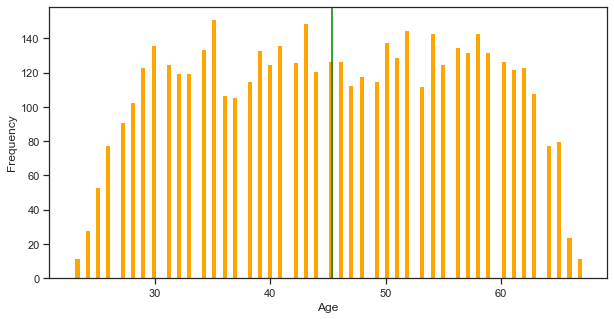

```
Unique elements in column "Age"
 [25 45 39 35 37 53 50 34 65 29 48 59 67 60 38 42 46 55 56 57 44 36 43 40
 30 31 51 32 61 41 28 49 47 62 58 54 33 27 66 24 52 26 64 63 23]
```

```python
# Mean an unique values Age group to target.
mean=Bank_data['Age'].mean()
print('Age- Mean: ',mean,"\n------------------------")
plt.figure(figsize=(10,5)) # set the figure size
plt.hist(Bank_data['Age'],bins=100,color='orange') #Plot the histogram
plt.axvline(mean,color='green',label='Mean')
plt.xlabel('Age')   # label the x-axis
plt.ylabel('Frequency')
plt.show()
Bank_data['Age'].describe()
unique_age = Bank_data['Age'].unique()
print('Unique elements in column "Age" ',"\n",unique_age)
```

### Observtion :

- As first target approach 3sigma of the mean curve, who don't have the loan can be reached out irrespect of other criteria.

### 3. Data Split

```python
from sklearn.linear_model import LinearRegression
from sklearn.model_selection import train_test_split
```

```python
#dropping/ignoring ZIP CODE AND ONLINE from data tabel
new_data= Bank_data.drop(['ZIP Code','Online','ID','CreditCard'],axis=1)
new_data.head(5)
```

|  | Age | Experience | Income | Family | CCAvg | Education | Mortgage | Personal Loan | Securities Account | CD Account |
| --- | --- | --- | --- | --- | --- | --- | --- | --- | --- | --- |
| 0 | 25 | 1.0 | 49 | 4 | 1.6 | 1 | 0 | 0 | 1 | 0 |
| 1 | 45 | 19.0 | 34 | 3 | 1.5 | 1 | 0 | 0 | 1 | 0 |
| 2 | 39 | 15.0 | 11 | 1 | 1.0 | 1 | 0 | 0 | 0 | 0 |
| 3 | 35 | 9.0 | 100 | 1 | 2.7 | 2 | 0 | 0 | 0 | 0 |
| 4 | 35 | 8.0 | 45 | 4 | 1.0 | 2 | 0 | 0 | 0 | 0 |

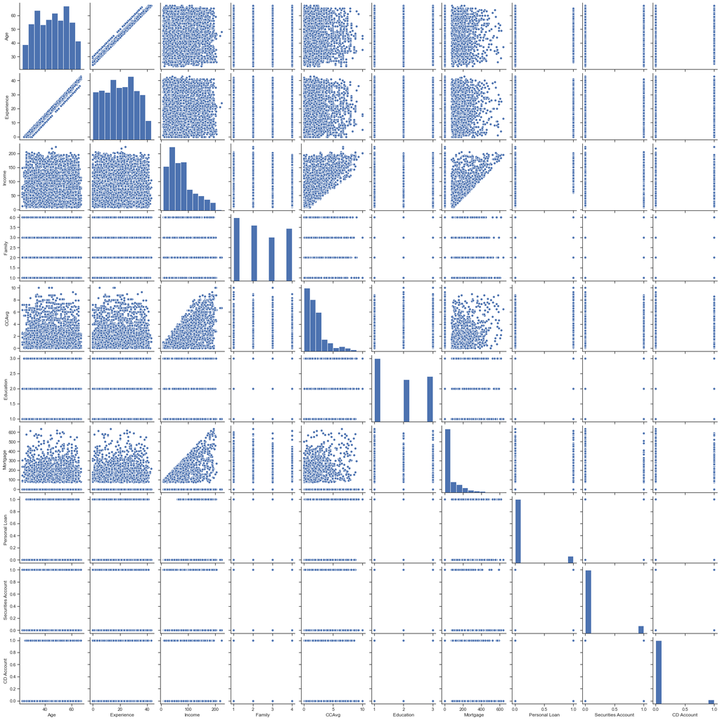

```python
sns.pairplot(new_data)
```

```python
# building a linear model
# independant variables
X = new_data.drop(['Personal Loan','Securities Account','Experience'], axis=1)
# the dependent variable
y = new_data[['Personal Loan']]
```

```python
X.head(5)
```

|  | Age | Income | Family | CCAvg | Education | Mortgage | CD Account |
| --- | --- | --- | --- | --- | --- | --- | --- |
| 0 | 25 | 49 | 4 | 1.6 | 1 | 0 | 0 |
| 1 | 45 | 34 | 3 | 1.5 | 1 | 0 | 0 |
| 2 | 39 | 11 | 1 | 1.0 | 1 | 0 | 0 |
| 3 | 35 | 100 | 1 | 2.7 | 2 | 0 | 0 |
| 4 | 35 | 45 | 4 | 1.0 | 2 | 0 | 0 |

```python
# Spliting X and y into training and test set in 50:50 ratio

X_train, X_test, y_train, y_test = train_test_split(X, y, test_size=0.50, random_state=1)
np.where(X.values >= np.finfo(np.float64).max)
```

```
(array([], dtype=int32), array([], dtype=int32))
```

```python
print('X variable shapes',"\n", X_train.shape)
print(X_test.shape,"\n-----------------")

print('Y Variable shapes',"\n",y_train.shape)
print(y_test.shape)
```

```
X variable shapes
 (2500, 7)
(2500, 7)
-----------------
Y Variable shapes
 (2500, 1)
(2500, 1)
```

### 4.A-- Modelling

```python
from sklearn.linear_model import LinearRegression # import the functions
lm=LinearRegression() #call the function
lm.fit(X_train,y_train)# fit the model
print("Intercept of the linear equation:",lm.intercept_) # see the intercept
print()

#see the error parameters
from sklearn.metrics import mean_absolute_error, mean_squared_error, r2_score

#make prediction
pred=lm.predict(X_train) #predicting values of y for all the xtest rows

print("Mean Absolute Error:",mean_absolute_error(y_test,pred))
print()
print("RMSE:",mean_squared_error(y_test,pred)**0.5)
print()
print("R2 Squarred:",r2_score(y_test, pred))
```

```
Intercept of the linear equation: [-0.39361406]

Mean Absolute Error: 0.22092728398892977

RMSE: 0.35106960821996314

R2 Squarred: -0.42550263120557985
```

```python
for idx, col_name in enumerate(X_train.columns):
    print("The coefficient for {} is {}".format(col_name, lm.coef_[0][idx]))
```

```
The coefficient for Age is 6.607662869721971e-05
The coefficient for Income is 0.0027978165949759885
The coefficient for Family is 0.030941494761956078
The coefficient for CCAvg is 0.018876990598377913
The coefficient for Education is 0.07708091781184345
The coefficient for Mortgage is 0.00011626293406470649
The coefficient for CD Account is 0.2875945155024273
```

```python
intercept = lm.intercept_[0]
print("The intercept for our model is {}".format(intercept))
```

```
The intercept for our model is -0.39361406364405294
```

#### Observation:

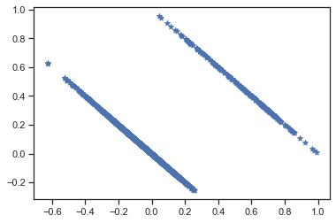

```python
import statsmodels.api as sm

X2 = sm.add_constant(X_train)
# sm.OLS by default does not add an intercept in the model.
#so we manually added it by the first line

lm= sm.OLS(y_train,X2).fit()
plt.scatter(lm.resid, lm.predict(),marker='*') # Plot between residual(actual - predicted) and predicted values
plt.show()
```

### 5.A -- Model measuring Parameter

```python
lm.score(X_train, y_train)
```

[output not shown]

```python
lm.score(X_test, y_test)
```

[output not shown]

```python
#RMSE
mean_squared_error(y_test,lm.predict(X_test))**0.5
```

[output not shown]

### 4 Logistic Regression Modelling

```python
from sklearn.feature_extraction.text import CountVectorizer
from sklearn.metrics import confusion_matrix, recall_score, precision_score, f1_score, roc_auc_score,accuracy_score
from sklearn.linear_model import LogisticRegression
from sklearn.metrics import accuracy_score
import os,sys
from scipy import stats
from sklearn import metrics
```

```python
logreg = LogisticRegression(random_state=42)
logreg.fit(X_train, y_train)
```

```
LogisticRegression(C=1.0, class_weight=None, dual=False, fit_intercept=True,
                   intercept_scaling=1, l1_ratio=None, max_iter=100,
                   multi_class='warn', n_jobs=None, penalty='l2',
                   random_state=42, solver='warn', tol=0.0001, verbose=0,
                   warm_start=False)
```

```python
y_predict = logreg.predict(X_test)
```

```python
## function to get confusion matrix in a proper format
def draw_cm( actual, predicted ):
    cm = confusion_matrix( actual, predicted)
    sns.heatmap(cm, annot=True,  fmt='.2f', xticklabels = [0,1] , yticklabels = [0,1] )
    plt.ylabel('Observed')
    plt.xlabel('Predicted')
    plt.show()
```

#### Measuring Parameters

```
Trainig accuracy 0.9432
----------
Testing accuracy 0.9428
----------
Confusion Matrix
```

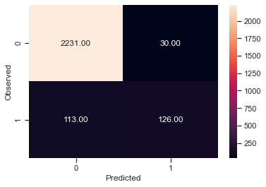

```
None
Recall: 0.5271966527196653
----------
Precision: 0.8076923076923077
----------
F1 Score: 0.6379746835443039
----------
Roc Auc Score: 0.7569640937194081
----------
```

```python
print("Trainig accuracy",logreg.score(X_train,y_train),"\n----------")

print("Testing accuracy",logreg.score(X_test, y_test),"\n----------")

print('Confusion Matrix')
print(draw_cm(y_test,y_predict))

print("Recall:",recall_score(y_test,y_predict),"\n----------")

print("Precision:",precision_score(y_test,y_predict),"\n----------")

print("F1 Score:",f1_score(y_test,y_predict),"\n----------")

print("Roc Auc Score:",roc_auc_score(y_test,y_predict),"\n----------")
```

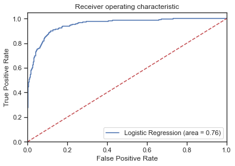

```python
#AUC ROC curve
from sklearn.metrics import roc_auc_score
from sklearn.metrics import roc_curve

logit_roc_auc = roc_auc_score(y_test, logreg.predict(X_test))
fpr, tpr, thresholds = roc_curve(y_test, logreg.predict_proba(X_test)[:,1])
plt.figure()
plt.plot(fpr, tpr, label='Logistic Regression (area = %0.2f)' % logit_roc_auc)
plt.plot([0, 1], [0, 1],'r--')
plt.xlim([0.0, 1.0])
plt.ylim([0.0, 1.05])
plt.xlabel('False Positive Rate')
plt.ylabel('True Positive Rate')
plt.title('Receiver operating characteristic')
plt.legend(loc="lower right")
plt.savefig('Log_ROC')
plt.show()
```

```python
# Checking Parameters of logistic regression
logreg.get_params()
```

```
{'C': 1.0,
 'class_weight': None,
 'dual': False,
 'fit_intercept': True,
 'intercept_scaling': 1,
 'l1_ratio': None,
 'max_iter': 100,
 'multi_class': 'warn',
 'n_jobs': None,
 'penalty': 'l2',
 'random_state': 42,
 'solver': 'warn',
 'tol': 0.0001,
 'verbose': 0,
 'warm_start': False}
```

```python
pip install yellowbrick
```

```python
train_score=[]
test_score=[]
solver = ['newton-cg','lbfgs','liblinear','sag','saga']
for i in solver:
    model = LogisticRegression(random_state=42,penalty='l2', C = 0.75,solver=i)  # changing values of solver
    model.fit(X_train, y_train)
    y_predict = model.predict(X_test)
    train_score.append(round(model.score(X_train, y_train),3))
    test_score.append(round(model.score(X_test, y_test),3))

print(solver,"\n")

print(train_score,"\n")

print(test_score,"\n")
```

```
['newton-cg', 'lbfgs', 'liblinear', 'sag', 'saga']

[0.947, 0.925, 0.942, 0.899, 0.898]

[0.946, 0.929, 0.94, 0.892, 0.89]
```

```python
train_score=[]
test_score=[]
solver = ['liblinear','saga']   # changing values of solver which works with 'l1'
for i in solver:
    model = LogisticRegression(random_state=42,penalty='l1', C = 0.75,solver=i)  #changed penalty to 'l1'
    model.fit(X_train, y_train)
    y_predict = model.predict(X_test)
    train_score.append(round(model.score(X_train, y_train),3))
    test_score.append(round(model.score(X_test, y_test),3))

print(solver,"\n")

print(train_score,"\n")

print(test_score,"\n")
```

```
['liblinear', 'saga']

[0.945, 0.898]

[0.947, 0.89]
```

```python
model = LogisticRegression(random_state=42,penalty='l1',solver='liblinear',class_weight='balanced') # changing class weight to balanced

model.fit(X_train, y_train)

y_predict = model.predict(X_test)

print("Trainig accuracy",model.score(X_train,y_train),"\n")

print("Testing accuracy",model.score(X_test, y_test))
```

```
Trainig accuracy 0.8996

Testing accuracy 0.8972
```

```python
# Running a loop to check different values of 'C'

train_score=[]
test_score=[]
C = [0.01,0.1,0.25,0.5,0.75,1]
for i in C:
    model = LogisticRegression(random_state=42,penalty='l1', solver='liblinear',class_weight='balanced', C=i)  # changing values of C
    model.fit(X_train, y_train)
    y_predict = model.predict(X_test)
    train_score.append(round(model.score(X_train,y_train),3)) # appending training accuracy in a blank list for every run of the loop
    test_score.append(round(model.score(X_test, y_test),3))   # appending testing accuracy in a blank list for every run of the loop

print(C,"\n")

print(train_score,"\n")

print(test_score,"\n")
```

```
[0.01, 0.1, 0.25, 0.5, 0.75, 1]

[0.797, 0.892, 0.899, 0.9, 0.9, 0.9]

[0.786, 0.892, 0.897, 0.898, 0.898, 0.897]
```

```python
# final model is
model = LogisticRegression(random_state=42,penalty='l1', solver='liblinear', class_weight='balanced',C=0.5)
model.fit(X_train, y_train)
y_predict = model.predict(X_test)
print("Trainig accuracy",model.score(X_train,y_train),"\n----------")

print("Testing accuracy",model.score(X_test, y_test),"\n----------")

print("Recall:",recall_score(y_test,y_predict),"\n----------")

print("Precision:",precision_score(y_test,y_predict),"\n----------")

print("F1 Score:",f1_score(y_test,y_predict),"\n----------")

print("Roc Auc Score:",roc_auc_score(y_test,y_predict),"\n----------")
```

```
Trainig accuracy 0.9004
----------
Testing accuracy 0.898
----------
Recall: 0.8786610878661087
----------
Precision: 0.481651376146789
----------
F1 Score: 0.6222222222222221
----------
Roc Auc Score: 0.8893526580418558
----------
```

```
< ---- Confusion Matrix ---- >
```

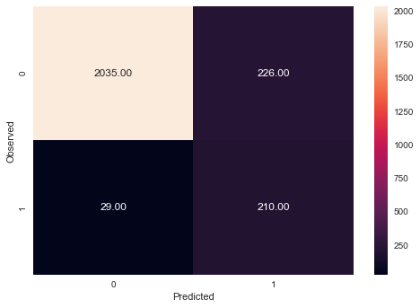

```
None
```

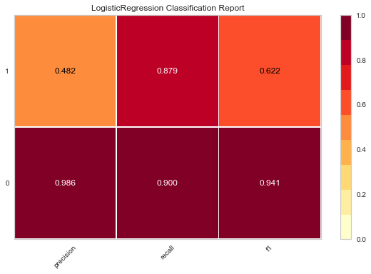

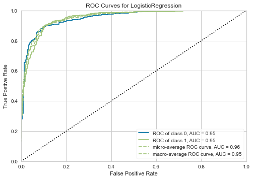

```python
from yellowbrick.classifier import ClassificationReport, ROCAUC
# Visualize model performance with yellowbrick library

print('< ---- Confusion Matrix ---- >')
print(draw_cm(y_test,y_predict))

viz = ClassificationReport(model)
viz.fit(X_train, y_train)
viz.score(X_test, y_test)
viz.show()

roc = ROCAUC(model)
roc.fit(X_train, y_train)
roc.score(X_test, y_test)
roc.show()
```

#### Business Insite:

- With respect to the above model predictions and from the confusion matrix (FN condition), another 29 customers can be offered Personal loans